# Part A: CIFAR-10 Image Generation with GAN

- Tan Yu Hoe
- 2026309
- DAAA/FT/2B/04

## Background Information

**CIFAR-10 dataset** (Canadian Institute for Advanced Research) is a collection of images that are commonly used to train and benchmark image classification algorithms. It is a subset of 80 million tiny images dataset and consists of 60,000 $32 \times 32$ color images in 10 different classes. There are 50000 training images and 10000 test images. It was collected by Alex Krizhevsky, Vinod Nair, and Geoffrey Hinton. [1]

## Define the Generative Task

> The generative task to generate 1000 small colour images based on the CIFAR-10 datasets, which consists of animals and transportations. The dataset provided also comes with labels, which is useful for generating samples.

## Motivation

The motivation of this notebook is to build a generative network that is able to capture the data distribution of the CIFAR-10 dataset and reproduce it for image generation. The generative network in this case would be based on a typical DCGAN architecture - a discriminative model, generative model, and cross entropy loss funtion.

- [1] A. Krizhevsky, “Learning Multiple Layers of Features from Tiny Images”, bll 32–33, 2009.

```python
# DL modules
import tensorflow as tf
from tensorflow import keras
from tensorflow.keras.layers import *
from tensorflow.keras import Sequential, Model
import keras.backend as K
from tensorflow.keras.initializers import RandomNormal
! pip install tensorflow_addons
from tensorflow_addons.layers import SpectralNormalization

# relevent libraries
import numpy as np
import matplotlib.pyplot as plt
import seaborn as sns
import pandas as pd
from tqdm.notebook import tqdm
import os

## matplotlib stylings
plt.rcParams['figure.figsize'] = 12, 8
```

# Training on a Tesla P100-PCIE-16GB

There are quite a lot of limitation of using my `NVIDIA GeForce GTX 1050` to trian the model, in terms of training time. Due to my insufficient hardware capability, I decided to switch over to Google Colab where there is a `Tesla P100` available for me, which provided me the resources to train a deeper neural network.

! Important Note: Make sure that you have Tensorflow-GPU, CUDA, and cuDNN enabled before running this notebook.

```
pip install tensorflow cudatoolkit=10.2 cudnn
```

```python
! nvidia-smi
```

```
Thu Jan 27 13:59:48 2022
+-----------------------------------------------------------------------------+
| NVIDIA-SMI 495.46       Driver Version: 460.32.03    CUDA Version: 11.2     |
|-------------------------------+----------------------+----------------------+
| GPU  Name        Persistence-M| Bus-Id        Disp.A | Volatile Uncorr. ECC |
| Fan  Temp  Perf  Pwr:Usage/Cap|         Memory-Usage | GPU-Util  Compute M. |
|                               |                      |               MIG M. |
|===============================+======================+======================|
|   0  Tesla P100-PCIE...  Off  | 00000000:00:04.0 Off |                    0 |
| N/A   64C    P0    33W / 250W |      0MiB / 16280MiB |      0%      Default |
|                               |                      |                  N/A |
+-------------------------------+----------------------+----------------------+

+-----------------------------------------------------------------------------+
| Processes:                                                                  |
|  GPU   GI   CI        PID   Type   Process name                  GPU Memory |
|        ID   ID                                                   Usage      |
|=============================================================================|
|  No running processes found                                                 |
+-----------------------------------------------------------------------------+
```

```python
# Checking if GPU is available
from tensorflow.python.client import device_lib
print(device_lib.list_local_devices())
```

```
[name: "/device:CPU:0"
device_type: "CPU"
memory_limit: 268435456
locality {
}
incarnation: 5083172654283724673
xla_global_id: -1
, name: "/device:GPU:0"
device_type: "GPU"
memory_limit: 16154099712
locality {
  bus_id: 1
  links {
  }
}
incarnation: 311525021417237918
physical_device_desc: "device: 0, name: Tesla P100-PCIE-16GB, pci bus id: 0000:00:04.0, compute capability: 6.0"
xla_global_id: 416903419
]
```

# Metadata

Each image is 32 pixels in height, 32 pixels in width and 3 colour channels (RGB), for a total of 3072 pixels in total. Each pixel contains an integer value, between 0 and 255. There are a total of 10 classes within the dataset, the classes are represented as:

| Label | Class | Label | Class |
| --- | --- | --- | --- |
| 0 | airplane | 5 | dog |
| 1 | automobile | 6 | frog |
| 2 | bird | 7 | horse |
| 3 | cat | 8 | ship |
| 4 | deer | 9 | truck |

```python
# import dataset
(x_train, y_train), (x_test, y_test) = tf.keras.datasets.cifar10.load_data()

classes = {
    0: 'Airplane',  1: 'Automobile',
    2: 'Bird',      3: 'Cat',
    4: 'Deer',      5: 'Dog',
    6: 'Frog',      7: 'Horse',
    8: 'Ship',      9: 'Truck'
}

y_train = y_train.reshape(-1)
y_test  = y_test.reshape(-1)

print('Dataset Loaded')
```

```
Dataset Loaded
```

# Exploratory Data Analysis

Before implementing a GAN, it would be essential to conduct an **exploratory data analysis** to discover any features/abnomalities of the data which could affect the development process. Here, I've set some objectives guiding objectives,

- What is the **Shape/Aspect Ratio** of the CIFAR dataset?
- What would the **Class Distribution** be like?
- Does the **Image** match with their respective **Labels**?
- What would be the **Mean Image per Class** be like?

```python
for i in [x_train, y_train, x_test, y_test]:
    print("Shape:", i.shape)
    print("Data Type:", i.dtype)
    print("Class:", type(i))
    print('Max Value:', i.max())
    print('Min Value:', i.min())
    print("---")
```

```
Shape: (50000, 32, 32, 3)
Data Type: uint8
Class: <class 'numpy.ndarray'>
Max Value: 255
Min Value: 0
---
Shape: (50000,)
Data Type: uint8
Class: <class 'numpy.ndarray'>
Max Value: 9
Min Value: 0
---
Shape: (10000, 32, 32, 3)
Data Type: uint8
Class: <class 'numpy.ndarray'>
Max Value: 255
Min Value: 0
---
Shape: (10000,)
Data Type: uint8
Class: <class 'numpy.ndarray'>
Max Value: 9
Min Value: 0
---
```

Each image sample has a dimension of (32, 32, 3). The three channels are presumed to be RGB colour channels. There are 50,000 samples in the train set and 10,000 samples in the test set.

```python
# Generating the Class Distribution for Train Set
## Class, Count, Proportion
unique, counts = np.unique(y_train, return_counts=True)
for u, c in tqdm(zip(unique, counts), total=len(unique), desc='Train Set'):
    print('Class: {:<10}'.format(classes[u]), 'Count: {:<10}'.format(c), 'Proportion: {:<10.1%}'.format(c/len(y_train)))

# Generating the Class Distribution for Test Set
## Class, Count, Proportion
unique, counts = np.unique(y_test, return_counts=True)
for u, c in tqdm(zip(unique, counts), total=len(unique), desc='Test Set'):
    print('Class: {:<10}'.format(classes[u]), 'Count: {:<10}'.format(c), 'Proportion: {:<10.1%}'.format(c/len(y_test)))
```

```
Class: Airplane   Count: 5000       Proportion: 10.0%
Class: Automobile Count: 5000       Proportion: 10.0%
Class: Bird       Count: 5000       Proportion: 10.0%
Class: Cat        Count: 5000       Proportion: 10.0%
Class: Deer       Count: 5000       Proportion: 10.0%
Class: Dog        Count: 5000       Proportion: 10.0%
Class: Frog       Count: 5000       Proportion: 10.0%
Class: Horse      Count: 5000       Proportion: 10.0%
Class: Ship       Count: 5000       Proportion: 10.0%
Class: Truck      Count: 5000       Proportion: 10.0%
```

```
Class: Airplane   Count: 1000       Proportion: 10.0%
Class: Automobile Count: 1000       Proportion: 10.0%
Class: Bird       Count: 1000       Proportion: 10.0%
Class: Cat        Count: 1000       Proportion: 10.0%
Class: Deer       Count: 1000       Proportion: 10.0%
Class: Dog        Count: 1000       Proportion: 10.0%
Class: Frog       Count: 1000       Proportion: 10.0%
Class: Horse      Count: 1000       Proportion: 10.0%
Class: Ship       Count: 1000       Proportion: 10.0%
Class: Truck      Count: 1000       Proportion: 10.0%
```

There is a uniform distribution between the 10 classes. There should not be any case of bias towards one particular class.

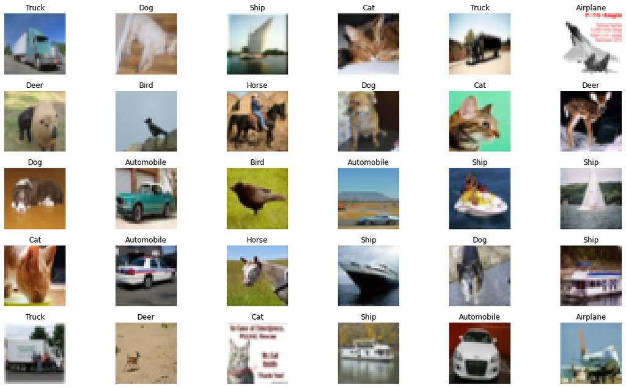

```python
# randomly samples 30 images and plot them out; CLT states 30 samples would be enough
fig = plt.figure(figsize=(16, 9), tight_layout=True)
for i in tqdm(range(30), total=30, desc='Display 30 Images'):
    rand_idx = np.random.randint(0, len(x_train))
    ax = fig.add_subplot(5, 6, i+1)
    ax.imshow(x_train[rand_idx])
    ax.set_title('{}'.format(classes[np.squeeze(y_train)[rand_idx]]))
    ax.axis('off')
plt.show()
```

From the 30 drawn samples (30 due to Central Limit Theorem), we could see a general trend which the labels tend to match with the image given despite the low resolution. We could make an assumption that the rest of the population would follow the same trend of having matching labels and image.

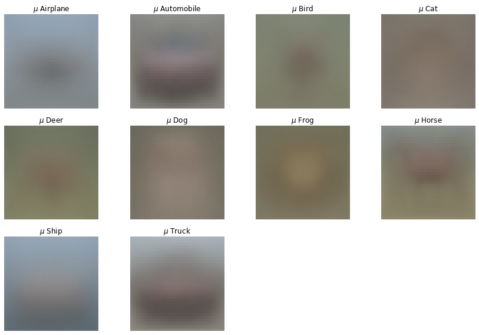

```python
# displaying the mean average per class (TRAIN SET)
fig = plt.figure(figsize=(12, 8), tight_layout=True)
n = 3
for idx in tqdm(classes.keys(), total=len(classes), desc='Mean Image per Class'):
    ax = fig.add_subplot(n, np.ceil(len(classes)/n), idx+1)
    ax.imshow(np.mean(x_train[np.squeeze(y_train)==idx]/255.0, axis=0))
    ax.set_title(r'$\mu$ {}'.format(classes[idx]))
    ax.axis('off')
plt.show()
```

Despite the mean images per class being blurry, we could see some edges that could make out of an object (e.g. this case would be the automobile, horse, and truck). This could mean the eventually trained network would likely to have a better ability in reproducing classes with significant representation/distribution.

# Feature Engineering

> Essentially, this section is purposed for preparing the data before feeding it into the model. This is done to increase data quality for increased performance in training.
- Pixel Normalization / Rescaling

$$X' = a + \frac{(X - X_{min})(b - a)}{X_{max} - X_{min}} = -1 + \frac{(X - 0)(1 - (-1))}{255 - 0} = -1 + \frac{X}{127.5}$$

where $X$ represents the pixel intensity values, $b$ is the upper bound of the pre-defined range, $a$ is the lower bound of the pre-defined range.

For Generative Adversarial Networks, it is recommended to use hyperbolic tangent `tanh` activation function in the output layer from the generator model. Given the saturating activation function provides an output range of $[-1, 1]$, it would be recommended to scale down the image to a range $[-1, 1]$.

```python
# preprocessing function on images and labels
def preprocessing_func(x, y):
    # pixel normalization
    x = x.astype('float32')
    x /= 127.5
    x -= 1

    return x, y

x_train, y_train = preprocessing_func(x_train, y_train)
x_test, y_test = preprocessing_func(x_test, y_test)

for i in [x_train, y_train, x_test, y_test]:
    print("Shape:", i.shape)
    print("Data Type:", i.dtype)
    print("Class:", type(i))
    print('Max Value:', i.max())
    print('Min Value:', i.min())
    print("---")
```

```
Shape: (50000, 32, 32, 3)
Data Type: float32
Class: <class 'numpy.ndarray'>
Max Value: 1.0
Min Value: -1.0
---
Shape: (50000,)
Data Type: uint8
Class: <class 'numpy.ndarray'>
Max Value: 9
Min Value: 0
---
Shape: (10000, 32, 32, 3)
Data Type: float32
Class: <class 'numpy.ndarray'>
Max Value: 1.0
Min Value: -1.0
---
Shape: (10000,)
Data Type: uint8
Class: <class 'numpy.ndarray'>
Max Value: 9
Min Value: 0
---
```

# Baseline GAN

The network architecture in this case would comprise of two networks - (1) a generator and (2) a discriminator.

## Objective Function

1. Generator $G$: to reproduce **synthetic data samples** $x$ (similar to training data) from a **latent vector** $z$ (usually as a Gaussian noise).
2. Discriminator $D$: to distinguish samples from the real dataset and the generator.

The Generator $G$ and Discriminator $D$ both play a two player minimax game with value function $V(G,D)$, where the Generator minimizes a two-sample test objective ($p_{data}=p_{\theta}$) and the discriminator maximizes the objective ($p_{data} \neq p_{\theta}$). Intuitively, the generator tries to fool the discriminator to the best of its ability by generating samples that look indisginguishable from $p_{data}$. [1] Formally, the objective function of a GAN is written as

$$\min _{G} \max _{D} V(D, G)=\mathbb{E}_{\boldsymbol{x} \sim p_{\text {data }}(\boldsymbol{x})}[\log D(\boldsymbol{x})]+\mathbb{E}_{\boldsymbol{z} \sim p_{\boldsymbol{z}}(\boldsymbol{z})}[\log (1-D(G(\boldsymbol{z})))]$$

- [1] I. J. Goodfellow et al., “Generative Adversarial Networks”, arXiv [stat.ML]. 2014.

```python
input_dim = (32, 32, 3) # dimensions of training images
latent_dim = 128        # dimensions of latent vectors aka Gaussian noise
```

## Discriminator

To put it into simple terms, a Discriminator is simply a binary classifier. It is used to classify between Real Images and Synthetic Images produced by the Generator. I've strutured the network such that it follows a typical CNN architecture. However, I've made some changes such that it is more suitabe for the GAN architecture.

- `2 by 2 Strided Convolutions`

In most common supervised Convolutional Neural Networks, pooling layers are used to downsample activation feature maps. However, this is not recommended for GAN as it could lead to some loss of information. For example, Max Pooling only takes in the largest value of each feature map while discarding the rest. For common DCGAN architectures, strided convolutions are used to downsample feature maps while withholding some information about the previous feature map.

- `Leaky ReLU` Activation Function

It was found that Leaky ReLU is more suitable as using ReLU would cause training to quickly saturate. [1] Leaky ReLU helps with training such that it would produce a value when the input value passed in is negative.

- `Batch Normalization`

GAN is well known for it's instability during training, sometimes there could be random spikes in loss during training. In order to mitigate this issue, I've used Batch Normalization to try to make training more stable by reducing covariate shifts, higher likelihood of avoiding mode collapse.

- `Spectral Normalization`

One issue of implementing GAN is the instability of its training. In 2018, the introduction of spectral normalization was proposed to stabilize the training of the discriminator. [2] Spectral Normalization since then have proven to be effective in training Adverserial Networks and its variations.

- `Gaussian Weights Initialization`

During my previous training attempts, it was found that the traditional approaches of using He and Xavier weights initialization are unsuitable for training as it makes training more unstable due to the larger distribution of weights. It was suggested in the multiple sources to use Gaussian Weight Initialization $N(\mu = 0, \sigma = 0.02)$ to reduce instability of training.

- [1] A. Radford, L. Metz, en S. Chintala, “Unsupervised Representation Learning with Deep Convolutional Generative Adversarial Networks”, arXiv [cs.LG]. 2016.
- [2] T. Miyato, T. Kataoka, M. Koyama, en Y. Yoshida, “Spectral Normalization for Generative Adversarial Networks”, arXiv [cs.LG]. 2018.

```python
# function to create discriminator model
def create_discriminator(image_size):
    weights_init = RandomNormal(mean=0, stddev=0.02)
    discriminator = Sequential([
        Input(shape=input_dim),

        ## 2 by 2 Strides for downsampling
        ## Leaky ReLU for Activation
        SpectralNormalization(
            Conv2D(64, kernel_size=4, strides=2, padding='same', kernel_initializer=weights_init)
        ),
        BatchNormalization(momentum=0.8),
        LeakyReLU(0.2),

        # Conv 2
        SpectralNormalization(
            Conv2D(128, kernel_size=4, strides=2, padding='same', kernel_initializer=weights_init)
        ),
        BatchNormalization(momentum=0.8),
        LeakyReLU(0.2),

        # Conv 3
        SpectralNormalization(
            Conv2D(256, kernel_size=4, strides=2, padding='same', kernel_initializer=weights_init)
        ),
        BatchNormalization(momentum=0.8),
        LeakyReLU(0.2),

        # # Conv 4
        SpectralNormalization(
            Conv2D(512, kernel_size=4, strides=2, padding='same', kernel_initializer=weights_init)
        ),
        BatchNormalization(momentum=0.8),
        LeakyReLU(0.2),

        GlobalMaxPooling2D(),
        Dense(1, activation='sigmoid'),
    ], name='discriminator_GAN')
    return discriminator
create_discriminator(image_size=input_dim).summary()
```

```
Model: "discriminator_GAN"
_________________________________________________________________
 Layer (type)                Output Shape              Param #
=================================================================
 spectral_normalization (Spe  (None, 16, 16, 64)       3200
 ctralNormalization)

 batch_normalization (BatchN  (None, 16, 16, 64)       256
 ormalization)

 leaky_re_lu (LeakyReLU)     (None, 16, 16, 64)        0

 spectral_normalization_1 (S  (None, 8, 8, 128)        131328
 pectralNormalization)

 batch_normalization_1 (Batc  (None, 8, 8, 128)        512
 hNormalization)

 leaky_re_lu_1 (LeakyReLU)   (None, 8, 8, 128)         0

 spectral_normalization_2 (S  (None, 4, 4, 256)        524800
 pectralNormalization)

 batch_normalization_2 (Batc  (None, 4, 4, 256)        1024
 hNormalization)

 leaky_re_lu_2 (LeakyReLU)   (None, 4, 4, 256)         0

 spectral_normalization_3 (S  (None, 2, 2, 512)        2098176
 pectralNormalization)

 batch_normalization_3 (Batc  (None, 2, 2, 512)        2048
 hNormalization)

 leaky_re_lu_3 (LeakyReLU)   (None, 2, 2, 512)         0

 global_max_pooling2d (Globa  (None, 512)              0
 lMaxPooling2D)

 dense (Dense)               (None, 1)                 513

=================================================================
Total params: 2,761,857
Trainable params: 2,758,977
Non-trainable params: 2,880
_________________________________________________________________
```

## Generator

A Generator is slightly different from any neural architectures we have learnt so far (up until Janurary 2022). Its architecture comprises of multiple Convolution upscaler, similar to half of an Autoencoder. There are some key features of this architecture to take note.

- `Transposed Convolution Layer`

Tranposed Convolution, aka Deconvolution, it is a normal convolution going the opposite direction. The main purpose of the transposed convolution in the Generator is to perform upsampling operations, upsampling from the noise latent vector to a generated image.

- `Batch Normalization`

GAN is well known for it's instability during training, sometimes there could be random spikes in loss during training. In order to mitigate this issue, I've used Batch Normalization to try to make training more stable by reducing covariate shifts, higher likelihood of avoiding mode collapse.

- `Gaussian Weights Initialization`

During my previous training attempts, it was found that the traditional approaches of using He and Xavier weights initialization are unsuitable for training as it makes training more unstable due to the larger distribution of weights. It was suggested in the multiple sources to use Gaussian Weight Initialization $N(\mu = 0, \sigma = 0.02)$ to reduce instability of training.

- `PReLU Activation Function`

Below illustrates a typical Leaky ReLU activation

$$R\phi(x) = \begin{Bmatrix} x \ z > 0\\ \alpha x\ x <= 0 \end {Bmatrix}$$

normally $\alpha$ would be a constant for Leaky ReLU. Typically for Generators, we would use ReLU as activation function throughout the network. However, this could cause certain effects like the Dying Activation effot due to sparse gradients during GAN training. To mitigate this effect, PReLU is introduced with $\alpha$ as a learning parameter to help training.

```python
# function to create generator model
def create_generator(latent_dim):

    # gaussian weights initialization
    weights_init = RandomNormal(mean=0, stddev=0.02)

    generator = Sequential([
        # fc block: handling latent vector z
        Input(shape=(latent_dim,)),
        Dense(2*2*512),
        Reshape((2, 2, 512)),

        # Conv 1
        ## using a kernel size that is a factor of the stride
        Conv2DTranspose(256, kernel_size=4, strides=2, padding='same', kernel_initializer=weights_init),
        BatchNormalization(momentum=0.8),
        PReLU(),

        # Conv 2
        Conv2DTranspose(128, kernel_size=4, strides=2, padding='same', kernel_initializer=weights_init),
        BatchNormalization(momentum=0.8),
        PReLU(),

        # Conv 3
        Conv2DTranspose(64, kernel_size=4, strides=2, padding='same', kernel_initializer=weights_init),
        BatchNormalization(momentum=0.8),
        PReLU(),

        # Output Layer
        Conv2DTranspose(3, kernel_size=4, strides=2, padding='same', activation='tanh', kernel_initializer=weights_init)
    ], name='generator_GAN')
    return generator

create_generator(latent_dim=latent_dim).summary()
```

```
Model: "generator_GAN"
_________________________________________________________________
 Layer (type)                Output Shape              Param #
=================================================================
 dense_1 (Dense)             (None, 2048)              264192

 reshape (Reshape)           (None, 2, 2, 512)         0

 conv2d_transpose (Conv2DTra  (None, 4, 4, 256)        2097408
 nspose)

 batch_normalization_4 (Batc  (None, 4, 4, 256)        1024
 hNormalization)

 p_re_lu (PReLU)             (None, 4, 4, 256)         4096

 conv2d_transpose_1 (Conv2DT  (None, 8, 8, 128)        524416
 ranspose)

 batch_normalization_5 (Batc  (None, 8, 8, 128)        512
 hNormalization)

 p_re_lu_1 (PReLU)           (None, 8, 8, 128)         8192

 conv2d_transpose_2 (Conv2DT  (None, 16, 16, 64)       131136
 ranspose)

 batch_normalization_6 (Batc  (None, 16, 16, 64)       256
 hNormalization)

 p_re_lu_2 (PReLU)           (None, 16, 16, 64)        16384

 conv2d_transpose_3 (Conv2DT  (None, 32, 32, 3)        3075
 ranspose)

=================================================================
Total params: 3,050,691
Trainable params: 3,049,795
Non-trainable params: 896
_________________________________________________________________
```

## Training Process

This training process describes a single iteration of weight update over a batch.

**Discriminator Weight Update**

1. Generator generates a batch of samples $G(z)$ using latent noise vector $z$.
2. Discriminator goes through a full iteration of forward propagation using $x$ (Real Images) and $G(z)$ (Generated Images), labelled as $1$ and $0$ respectively.
3. Discriminator computes the loss function, usually cross entropy, then backpropagates to update the weights using partial derivatives.

[output not shown]

**Generator Weight Update**

1. Generator generates another batch of sample $G(z)$ using the latent noise vector.
2. Discriminator computes their discrimination using $D(G(z))$
3. Loss function is then applied between $D(G(z))$ and $1$. ( usedto represent real images) The intuition would be having the generator working towards generating an image to be discriminated as $1$.
4. Compute the generator's weights using the loss function, then update the generator weights via backpropagation.

[output not shown]

```python
# Code Source: https://www.tensorflow.org/guide/keras/customizing_what_happens_in_fit#wrapping_up_an_end-to-end_gan_example
class GAN(Model):
    def __init__(self, discriminator, generator, latent_dim):
        super(GAN, self).__init__()
        self.discriminator = discriminator
        self.generator = generator
        self.latent_dim = latent_dim
        self.gen_loss_tracker = keras.metrics.Mean(name='generator_loss')
        self.disc_loss_tracker = keras.metrics.Mean(name='discriminator_loss')
        self.kl = tf.keras.metrics.KLDivergence()

    def compile(self, d_optimizer, g_optimizer, loss_fn):
        super(GAN, self).compile()
        self.d_optimizer = d_optimizer
        self.g_optimizer = g_optimizer
        self.loss_fn = loss_fn

    def train_step(self, real_images):
        ### TRAINING DISCRIMINATOR
        if isinstance(real_images, tuple):
            real_images = real_images[0]
        # Sample random points in the latent space
        batch_size = tf.shape(real_images)[0]
        random_latent_vectors = tf.random.normal(shape=(batch_size, self.latent_dim))

        # Decode them to fake images
        generated_images = self.generator(random_latent_vectors)

        # Combine them with real images
        combined_images = tf.concat([generated_images, real_images], axis=0)

        # Assemble labels discriminating real from fake images
        labels = tf.concat(
            [tf.zeros((batch_size, 1)), tf.ones((batch_size, 1))], axis=0
        )
        # Add random noise to the labels - important trick!
        labels += 0.05 * tf.random.uniform(tf.shape(labels))

        # Train the discriminator
        with tf.GradientTape() as tape:
            predictions = self.discriminator(combined_images)
            d_loss = self.loss_fn(labels, predictions)
        grads = tape.gradient(d_loss, self.discriminator.trainable_weights)
        self.d_optimizer.apply_gradients(
            zip(grads, self.discriminator.trainable_weights)
        )

        ### TRAINING GENERATOR
        # Sample random points in the latent space
        random_latent_vectors = tf.random.normal(shape=(batch_size, self.latent_dim))

        # Assemble labels that say "all real images"
        misleading_labels = tf.ones((batch_size, 1))

        # Train the generator (note that we should *not* update the weights
        # of the discriminator)!
        with tf.GradientTape() as tape:
            generated_images = self.generator(random_latent_vectors)
            predictions = self.discriminator(generated_images)
            g_loss = self.loss_fn(misleading_labels, predictions)
        grads = tape.gradient(g_loss, self.generator.trainable_weights)
        self.g_optimizer.apply_gradients(zip(grads, self.generator.trainable_weights))

        # Monitor Loss
        self.disc_loss_tracker.update_state(d_loss)
        self.gen_loss_tracker.update_state(g_loss)
        self.kl.update_state(y_true=real_images, y_pred=generated_images)

        return {
            "d_loss": self.disc_loss_tracker.result(),
            "g_loss": self.gen_loss_tracker.result(),
            "KL Divergence": self.kl.result(),
        }
```

## Callback Functions

- `GAN Monitor`

This callback function is used to display a figure of sample Synthetic Images generated by the Generative Model after $n$ epochs and the training process. This is used monitor the GAN training, to see if there is any improvement through the gradient descent or ascent process.

Another functionality of this callback function is to save the generator's weights every $n$ epochs. This is used to checkpoint the generator's weights, which is then restored at a later point. The reason for this would be most people found the best performing generator in the middle of the training process, rather than the end.

```python
# Custom callback to monitor the Generator at every n epoch
class GANMonitor(keras.callbacks.Callback):
    # class GANMontor
    # - num_img: number of images generated using matplotlib figure
    # - latent_dim: dimensions of noise latent vector passed into the generator
    # - patience: number of epochs to generate images
    # - vmin: minumum scaling factor, a
    # - vmax: maximum scaling factor, b
    # NOTE: only compatible with the GAN class I've set up
    def __init__(self, num_img=10, latent_dim=128, patience=10, vmin=0, vmax=1):
        self.num_img = num_img
        self.latent_dim = latent_dim
        self.patience = patience
        self.vmin = vmin
        self.vmax = vmax
        self.constant_latent_vector = tf.random.normal(shape=(self.num_img, self.latent_dim))

    # method to generate images and display them as matplotlib figure
    def generate_plot(self):
        # Generate Images
        generated_images = self.model.generator(self.constant_latent_vector)

        # Normalise Image from [vmin, vmax] to [0, 1]
        generated_images -= self.vmin
        generated_images /= (self.vmax - self.vmin)

        # Generate Matplotlib Figure
        row_size = np.ceil(self.num_img/5)
        fig = plt.figure(figsize=(10, 2*row_size), tight_layout=True)
        for i in range(self.num_img):
            ax = fig.add_subplot(row_size, 5, i+1)
            ax.imshow(generated_images[i])
            ax.axis('off')
        plt.show()

    # method to save generator's weights
    def save_weights(self, epoch=None):
        try:
            if epoch != None:
                name='generator-epoch-{}.h5'.format(epoch)
                print('Generator Checkpoint - {}'.format(name))
                self.model.generator.save_weights(
                    filepath=name,
                    save_format='h5'
                )
        except Exception as e:
            print(e)

    # generate a plot every n epochs
    def on_epoch_begin(self, epoch, logs=None):
        if epoch % self.patience == 0:
            self.generate_plot()
            self.save_weights(epoch)

    # generate a plot after training
    def on_train_end(self, epoch, logs=None):
        self.generate_plot()
        self.save_weights('Full Train')
```

```python
# List of Callback Functions
callbacks = [
    GANMonitor(num_img=15, latent_dim=128, patience=5, vmin=-1, vmax=1),
]
```

## Training a GAN

Training an Adverserial Network can take a long period, as it is training two neural networks simultaneously. As such, I want to try optimizing training speed such that it doesn't take too long to train finish an adverserial network. In order to do this, I will be heavily utilising parallelization, prefetching, and batching from `tf.data.Dataset` in hopes for better training time optimization. (`tf.data.AUTOTUNE`)

Main Source: https://www.tensorflow.org/api_docs/python/tf/data/Dataset

#### Adam Optimizer

A common practice while implementing GAN to be using Adam optimization algorithm with a small learning rate of $\alpha = 0.0002$ for stable training. It was also found that the default momentum was making training unstable, as such $\beta_1 = 0.5$ is used instead.

```python
# Hyperparameters and Constants
BATCH_SIZE  = 64
LATENT_DIM  = 128
AUTO        = tf.data.AUTOTUNE
EPOCHS      = 100
BUFFER_SIZE = 1024
INPUT_DIM   = (32, 32, 3)
```

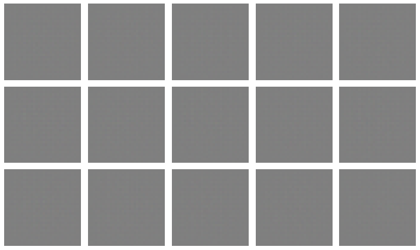

```
Generator Checkpoint - generator-epoch-0.h5
```

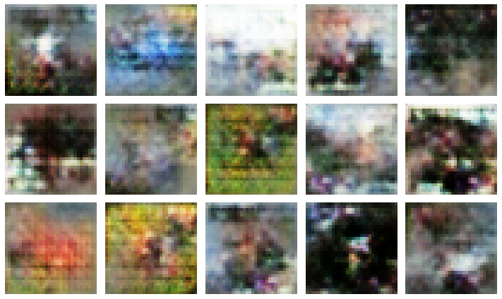

```
Generator Checkpoint - generator-epoch-5.h5
```

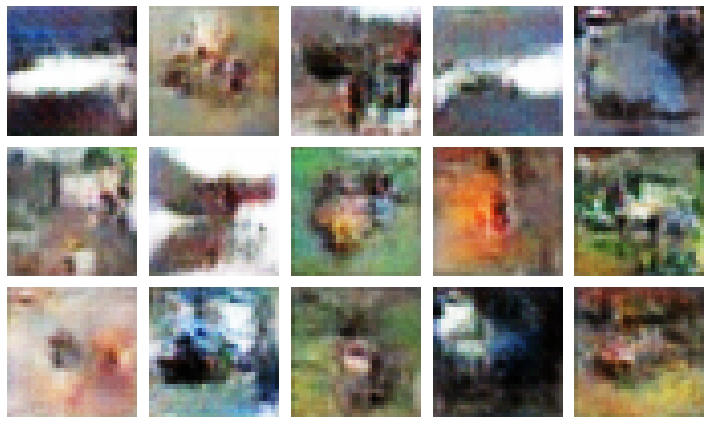

```
Generator Checkpoint - generator-epoch-10.h5
```

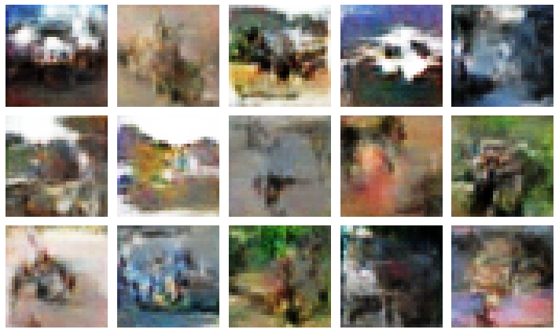

```
Generator Checkpoint - generator-epoch-15.h5
```

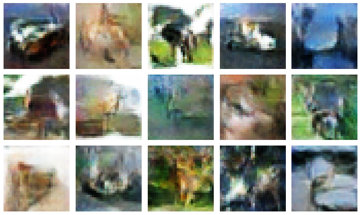

```
Generator Checkpoint - generator-epoch-20.h5
```

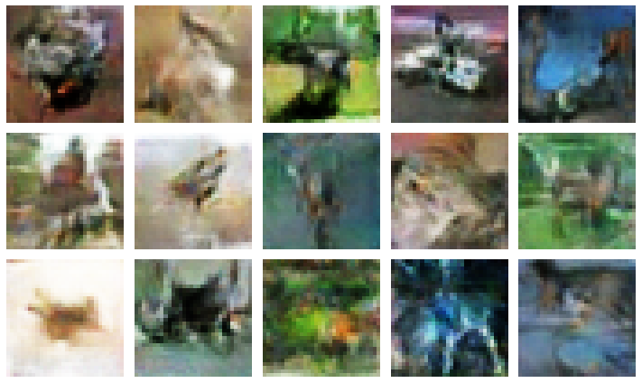

```
Generator Checkpoint - generator-epoch-25.h5
```

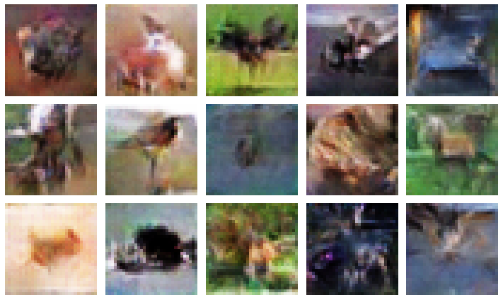

```
Generator Checkpoint - generator-epoch-30.h5
```

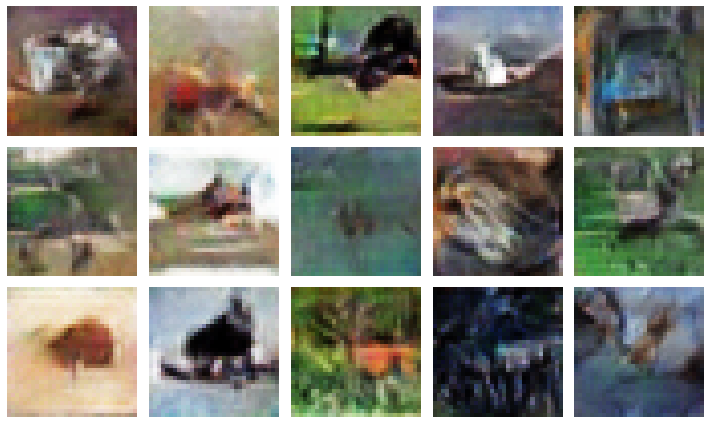

```
Generator Checkpoint - generator-epoch-35.h5
```

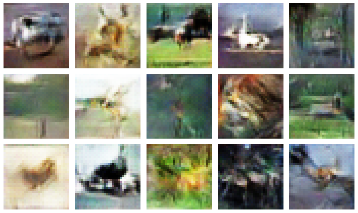

```
Generator Checkpoint - generator-epoch-40.h5
```

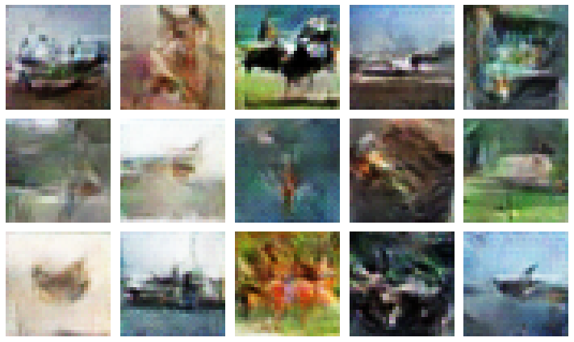

```
Generator Checkpoint - generator-epoch-45.h5
```

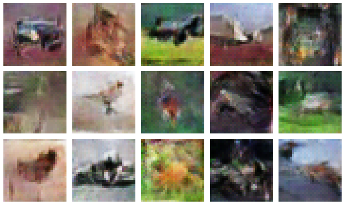

```
Generator Checkpoint - generator-epoch-50.h5
```

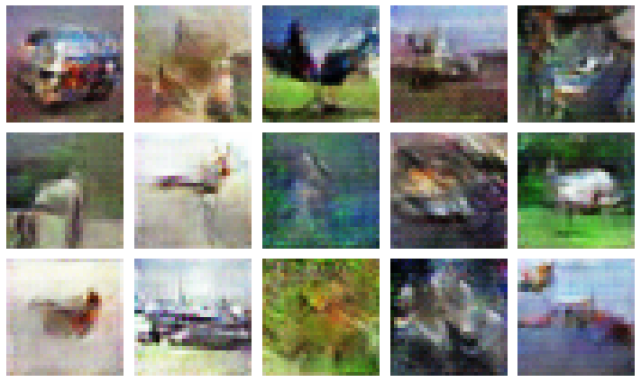

```
Generator Checkpoint - generator-epoch-55.h5
```

[9 more figures not shown]

```
Generator Checkpoint - generator-epoch-Full Train.h5
CPU times: user 25min 29s, sys: 1min 42s, total: 27min 12s
Wall time: 40min 1s
```

```python
%%time
# Reseting Graph variables
tf.keras.backend.clear_session()
K.clear_session()

# Creating a GAN class
gan = GAN(
    discriminator=create_discriminator(image_size=INPUT_DIM),
    generator=create_generator(latent_dim=LATENT_DIM),
    latent_dim=latent_dim
)
# Compiling with Optimizer and Loss Function
gan.compile(
    d_optimizer=keras.optimizers.Adam(learning_rate=2e-4, beta_1=0.5),
    g_optimizer=keras.optimizers.Adam(learning_rate=2e-4, beta_1=0.5),
    loss_fn=keras.losses.BinaryCrossentropy(),
)

# Preparing the Dataset with `tf.data`
dataset = tf.data.Dataset.from_tensor_slices(x_train)
dataset = dataset.shuffle(buffer_size=BUFFER_SIZE).batch(batch_size=BATCH_SIZE, num_parallel_calls=AUTO).prefetch(AUTO)

# Starting the Train Process
hist = gan.fit(dataset, epochs=EPOCHS, use_multiprocessing=True, workers=16, callbacks=callbacks)
```

# GAN Evaluation

An important step to building our model would be evaluating it's performance. However, it is still an open problem till this date on the best way to evaluate a GAN.

### Problems with GAN Evaluation

In supervised learning, there are a common evaluation metrics like Accuracy and Mean Squared Error used, as there are training and testing sets together with labels provided. However in GAN, there are no "labels" provided, the main focus would be on the quality of the synthetic image.

Another way of evaluating GANs would be using their objective functions $V(D, G)$, however the objective functions of most GAN architectures (e.g. CGAN, WGAN) are likely to be different.

### Manual GAN Evaluation

The simplest method on evaluating Synthetic Image quality, using our eyes 👀. Despite being the simplest and the go-to method for evaluation, there are some disadvantages when dealing with the CIFAR-10 dataset.

1. Method of evaluation is subjective, there might be some bias by the reviewer.
2. CIFAR-10 dataset and generated images comes as a shape (32, 32, 3), the low resolution makes it hard to differentiate between classes.
3. Difficult to review large quantity of images.
4. I, Tan Yu Hoe, am medically diagnosed to be colour-blind. It is hard for me to differentiate between the pixels.

With these issues that I can think of, I will still display the images but this method would not be my default way of evaluation.

### Quantitative GAN Evaluation

Evaluating GAN on quantitative means refers to using a specific calculation of specific numerical scores, used to summarize the general quality of the images.

Most of the metrics I will be mention have a similar concept in mind, just different ways of evaluation - the main idea would be comparing high dimensional data distribution between the Original Images used for training and the Synthetic Images generated from the Generative model.

In order to inplement this, I will be using the following metrics for evaluation.

- **KL Divergence** (aka relative entropy) - measures the distance between two statistical probability
- **Fréchet Inception Distance** - compares distribution of generated images

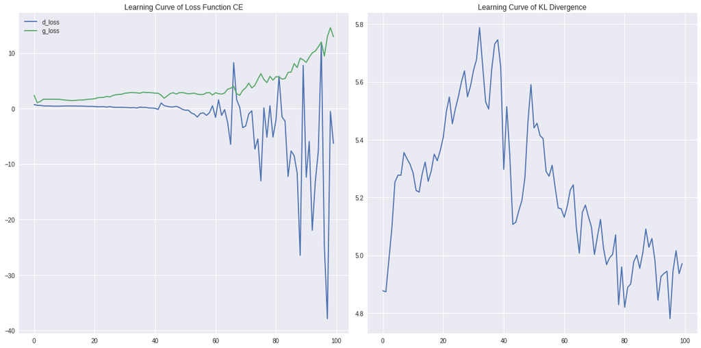

```python
# story history object into dataframe
hist_df = pd.DataFrame(hist.history)

# using pandas dataframe to plot out learning curve
with plt.style.context('seaborn'):
    fig, (ax1, ax2) = plt.subplots(1, 2, figsize=(16, 8), tight_layout=True)
    hist_df.loc[:, ["d_loss", 'g_loss']].plot(ax=ax1, title=r'Learning Curve of Loss Function CE')
    hist_df.loc[:, "KL Divergence"].plot(ax=ax2, title="Learning Curve of KL Divergence")
    plt.show()
```

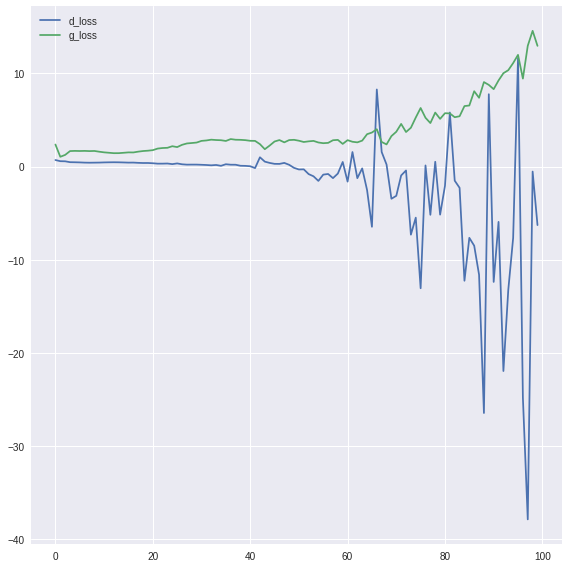

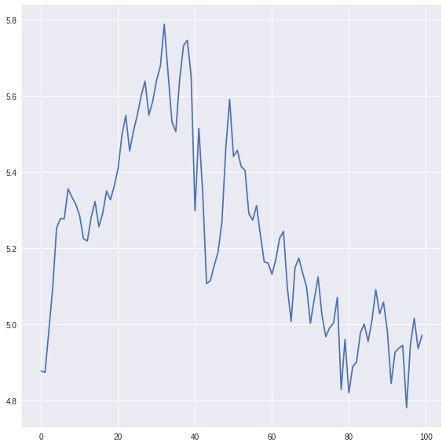

```python
# using pandas dataframe to plot out learning curve
with plt.style.context('seaborn'):
    for cols in [["d_loss", 'g_loss'], "KL Divergence"]:
        fig, ax = plt.subplots(1, 1, figsize=(8, 8), tight_layout=True)
        hist_df.loc[:, cols].plot(ax=ax)
        plt.show()
```

```python
# Loading Weights for best Generator
saved_weights = 'generator-epoch-40.h5'
gan.generator.load_weights(saved_weights)
gan.generator.summary()
```

```
Model: "generator_GAN"
_________________________________________________________________
 Layer (type)                Output Shape              Param #
=================================================================
 dense_1 (Dense)             (None, 2048)              264192

 reshape (Reshape)           (None, 2, 2, 512)         0

 conv2d_transpose (Conv2DTra  (None, 4, 4, 256)        2097408
 nspose)

 batch_normalization_4 (Batc  (None, 4, 4, 256)        1024
 hNormalization)

 p_re_lu (PReLU)             (None, 4, 4, 256)         4096

 conv2d_transpose_1 (Conv2DT  (None, 8, 8, 128)        524416
 ranspose)

 batch_normalization_5 (Batc  (None, 8, 8, 128)        512
 hNormalization)

 p_re_lu_1 (PReLU)           (None, 8, 8, 128)         8192

 conv2d_transpose_2 (Conv2DT  (None, 16, 16, 64)       131136
 ranspose)

 batch_normalization_6 (Batc  (None, 16, 16, 64)       256
 hNormalization)

 p_re_lu_2 (PReLU)           (None, 16, 16, 64)        16384

 conv2d_transpose_3 (Conv2DT  (None, 32, 32, 3)        3075
 ranspose)

=================================================================
Total params: 3,050,691
Trainable params: 3,049,795
Non-trainable params: 896
_________________________________________________________________
```

```
Latent Vector Dim: (1000, 128)	Generated Images Dim: (1000, 32, 32, 3)
```

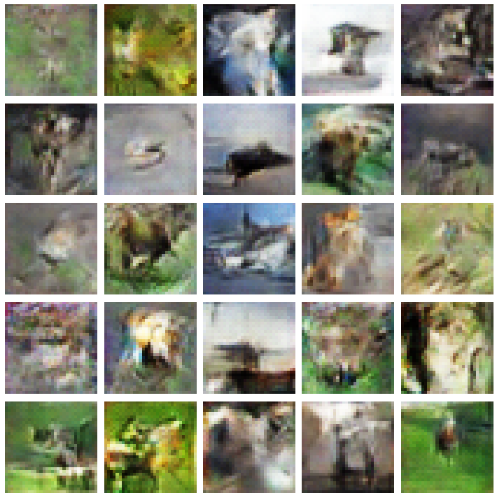

```python
# Generating 1000 Synthetic Images
random_noise = tf.random.normal(shape=(1000, latent_dim))
synthetic_images = gan.generator.predict(random_noise)
print("Latent Vector Dim: {}\tGenerated Images Dim: {}".format(random_noise.shape, synthetic_images.shape))

# Scaling back to [0, 1]
synthetic_images -= -1
synthetic_images /= (1 - (-1))

# Display 15 randomly sampled images
fig = plt.figure(figsize=(10, 10), tight_layout=True)
for i in range(25):
    rand_idx = np.random.randint(0, len(synthetic_images))
    ax = fig.add_subplot(5, 5, i+1)
    ax.imshow(synthetic_images[rand_idx])
    ax.axis('off')
plt.show()
```

## Evaluation using Fréchet inception distance (FID)

> Frechet Inception Distance is a metric used to access the quality of images created by the generator by comparing the distribution of the generated images with the distribution of real images that were used to train the generator.

FID operates by using a Wasserstein metric to compare between two high dimensional matrices/tensors. These matrices are generated using an Embedding generated by a pre-trained Inception model. The mean and covariance are extracted from the embeddings to be then computed as a metric. The formal metric are described below:

$$FID = ||\mu - \mu_w||^2_2 + tr(C + C_w - 2(C C_w)^\frac{1}{2})$$

```python
# import relevant libraries to calculate FID
import numpy as np
from tensorflow.keras.applications.inception_v3 import InceptionV3, preprocess_input
from tensorflow.image import resize
from scipy.linalg import sqrtm
import math
from tqdm.notebook import tqdm
import tensorflow as tf
```

```python
class GAN_FID:
    def __init__(self, batch_size, latent_dim, sample_size, buffer_size):
        # setting Hyperparameters
        self.BATCH_SIZE = batch_size
        self.LATENT_DIM = latent_dim
        self.SAMPLE_SIZE = sample_size
        self.BUFFER_SIZE = buffer_size

        # setting Constants
        self.INCEPTION_SHAPE = (299, 299, 3)
        self.INCEPTION = InceptionV3(include_top=False, pooling='avg', input_shape=self.INCEPTION_SHAPE)
        self.AUTO = tf.data.AUTOTUNE

    # method to set generator and training data
    def fit(self, generator, train_data):
        # setting generative model and original data used for training
        self.GENERATOR = generator
        self.train_data = train_data

        # Preparing Real Images
        trainloader = tf.data.Dataset.from_tensor_slices((self.train_data))
        trainloader = (
            trainloader
            .shuffle(self.BUFFER_SIZE)
            .map(self.__resize_and_preprocess, num_parallel_calls=self.AUTO)
            .batch(self.BATCH_SIZE, num_parallel_calls=self.AUTO)
            .prefetch(self.AUTO)
        )
        self.trainloader = trainloader

        # Generate and prepare Synthetic Images (Fake)
        noise = tf.random.normal([self.SAMPLE_SIZE, self.LATENT_DIM])
        generated_images = self.GENERATOR(noise)
        genloader = tf.data.Dataset.from_tensor_slices(generated_images)
        genloader = (
            genloader
            .map(self.__resize_and_preprocess, num_parallel_calls=self.AUTO)
            .batch(self.BATCH_SIZE, num_parallel_calls=self.AUTO)
            .prefetch(self.AUTO)
        )
        self.genloader = genloader

        # prepare embeddings
        count = math.ceil(self.SAMPLE_SIZE/self.BATCH_SIZE)

        ## compute embeddings for real images
        print("Computing Real Image Embeddings")
        self.real_image_embeddings = self.__compute_embeddings(self.trainloader, count)

        ## compute embeddings for generated images
        print("Computing Generated Image Embeddings")
        self.generated_image_embeddings = self.__compute_embeddings(self.genloader, count)
        assert self.real_image_embeddings.shape == self.generated_image_embeddings.shape, "Embeddings are not of the same size"
        print("Computed Embeddings\tReal Images Embedding Shape: {}\tGenerated Images Embedding Shape: {}".format(
            self.real_image_embeddings.shape,
            self.generated_image_embeddings.shape
        ))

    # method to produce evaluation results
    @tf.autograph.experimental.do_not_convert
    def evaluate(self):
        # calculate Frechet Inception Distance
        fid = self.__calculate_fid(self.real_image_embeddings, self.generated_image_embeddings)
        print('The computed FID score is:', fid)

        return fid

    # method to generate embeddings from inception model
    def __compute_embeddings(self, dataloader, count):
        image_embeddings = []
        for _ in tqdm(range(count)):
            images = next(iter(dataloader))
            embeddings = self.INCEPTION.predict(images)
            image_embeddings.extend(embeddings)
        return np.array(image_embeddings)

    ## STATIC METHODS: these methods knows nothing about the class
    # static method to prepare the data before computing Inception Embeddings
    @staticmethod
    def __resize_and_preprocess(image):
        # image *= 255.0 # original image are scaled to [0, 1], scaling back to [0, 255]
        image -= -1
        image /= (1 - (-1))
        image *= 255.

        # .preprocess_input() expects an image of scale [0, 255]
        image = preprocess_input(image)
        # inception model expects an image of shape (None, 299, 299, 3)
        image = tf.image.resize(image, (299, 299), method='nearest')
        return image

    # static method to calculate frechet inception distance based on embeddings
    @staticmethod
    def __calculate_fid(real_embeddings, generated_embeddings):
        # calculate mean and covariance statistics
        mu1, sigma1 = real_embeddings.mean(axis=0), np.cov(real_embeddings, rowvar=False)
        mu2, sigma2 = generated_embeddings.mean(axis=0), np.cov(generated_embeddings, rowvar=False)
        # calculate sum squared difference between means
        ssdiff = np.sum((mu1 - mu2)**2.0)
        # calculate sqrt of product between cov
        covmean = sqrtm(sigma1.dot(sigma2))
        # check and correct imaginary numbers from sqrt
        if np.iscomplexobj(covmean):
            covmean = covmean.real
        # calculate score
        fid = ssdiff + np.trace(sigma1 + sigma2 - 2.0 * covmean)
        return fid
```

```python
%%time
fid_class = GAN_FID(batch_size=512, latent_dim=128, sample_size=10000, buffer_size=1024)
fid_class.fit(generator=gan.generator, train_data=x_train)
fid_score = fid_class.evaluate()
```

```
Computing Real Image Embeddings
```

```
Computing Generated Image Embeddings
```

```
Computed Embeddings	Real Images Embedding Shape: (10240, 2048)	Generated Images Embedding Shape: (10240, 2048)
The computed FID score is: 135.78251705865497
CPU times: user 3min 22s, sys: 19.4 s, total: 3min 41s
Wall time: 1min 42s
```

# Save Generative Model

The final objective would be creating 1000 Synthetic Images, it would be my prefernce to have it done in another IPyhton Notebook.

```python
# summary information
gan.generator.summary()

# saving as .hdf format
gan.generator.save("GAN_Generator.h5")
assert os.path.exists('GAN_Generator.h5'), "GAN Generator does not exists"
```

```
Model: "generator_GAN"
_________________________________________________________________
 Layer (type)                Output Shape              Param #
=================================================================
 dense_1 (Dense)             (None, 2048)              264192

 reshape (Reshape)           (None, 2, 2, 512)         0

 conv2d_transpose (Conv2DTra  (None, 4, 4, 256)        2097408
 nspose)

 batch_normalization_4 (Batc  (None, 4, 4, 256)        1024
 hNormalization)

 p_re_lu (PReLU)             (None, 4, 4, 256)         4096

 conv2d_transpose_1 (Conv2DT  (None, 8, 8, 128)        524416
 ranspose)

 batch_normalization_5 (Batc  (None, 8, 8, 128)        512
 hNormalization)

 p_re_lu_1 (PReLU)           (None, 8, 8, 128)         8192

 conv2d_transpose_2 (Conv2DT  (None, 16, 16, 64)       131136
 ranspose)

 batch_normalization_6 (Batc  (None, 16, 16, 64)       256
 hNormalization)

 p_re_lu_2 (PReLU)           (None, 16, 16, 64)        16384

 conv2d_transpose_3 (Conv2DT  (None, 32, 32, 3)        3075
 ranspose)

=================================================================
Total params: 3,050,691
Trainable params: 3,049,795
Non-trainable params: 896
_________________________________________________________________
WARNING:tensorflow:Compiled the loaded model, but the compiled metrics have yet to be built. `model.compile_metrics` will be empty until you train or evaluate the model.
```

# Conclusion and Further Improvements

**Further Improvements**

- Adding Labels into training could improve training and identification. (Conditional GAN, InfoGAN, ACGAN)
- Changing Loss Function could perhaps improve results. (WGAN, WGAN-GP, LSGAN)